# Week 1 - Gaussians

## Paper

Bromiley, P.A. (2018) Products and Convolutions of Gaussian Probability Density Functions

## Gaussian components

First we want to see how gaussians are constructed. The formula for a gaussian PDF is:
$$f(x) = \frac{1}{\sqrt{2 \pi \sigma _f}} e^{-\frac{(x-\mu_f)^2}{2 \sigma_f^2}}$$
We can break this into two components:
$$a(x) = \frac{1}{\sqrt{2 \pi \sigma _f}}$$
$$b(x) = e^{-\frac{(x-\mu_f)^2}{2 \sigma_f^2}}$$

Let’s plot those components and see what the pieces look like.

### a(x)

We can see from the lack of dependence on $x$ that $a(x)$ will be constant:

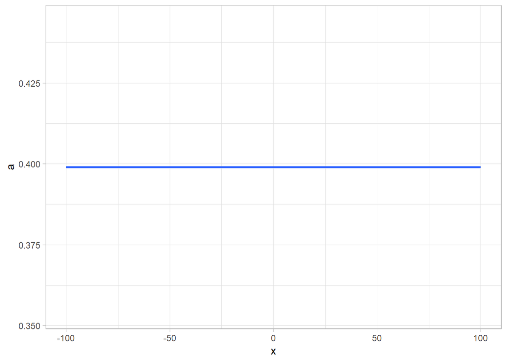

```r
x <- -100:100

fa <- function(x = NULL, sigma = 1, mu = 0) {
  1 / (sqrt(2 * pi * sigma))
}

# Plot
library(tidyverse)
d <- data.frame(x, a = sapply(x, fa))

ggplot(d, aes(x, a)) + geom_smooth() + theme_light()
```

### b(x)

$b(x)$ also occurs in the sigmoid function, recognizable from psychometric curves, so probably produces a curve. Let’s plot it:

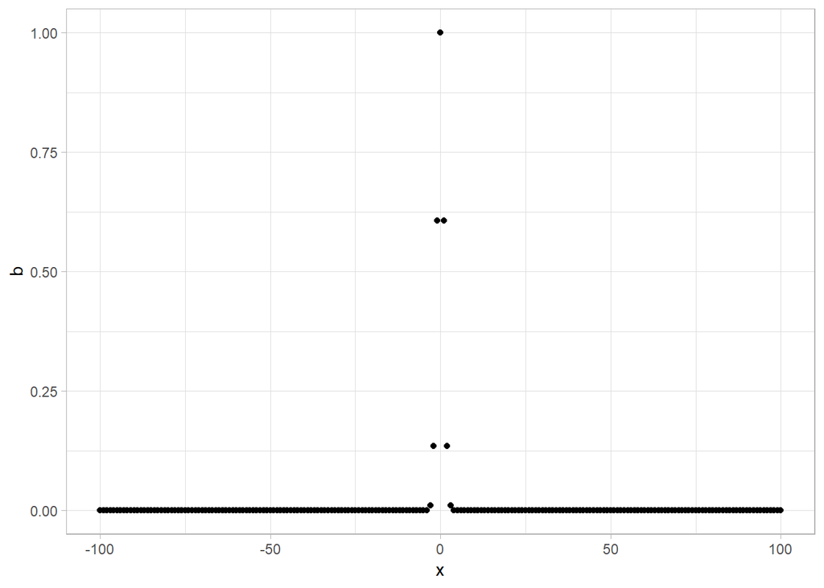

```r
fb <- function(x, sigma = 1, mu = 0) {
  exponent <- (x - mu) ^ 2 / (2 * sigma ^ 2)
  exp(1) ^ -exponent
}

d$b <- sapply(x, fb)

ggplot(d, aes(x, b)) + geom_point() + theme_light()
```

#### Zoom in

So the first thought is that our resolution is way off: values nearby 0 are the only interesting ones, so let’s zoom in on that area.

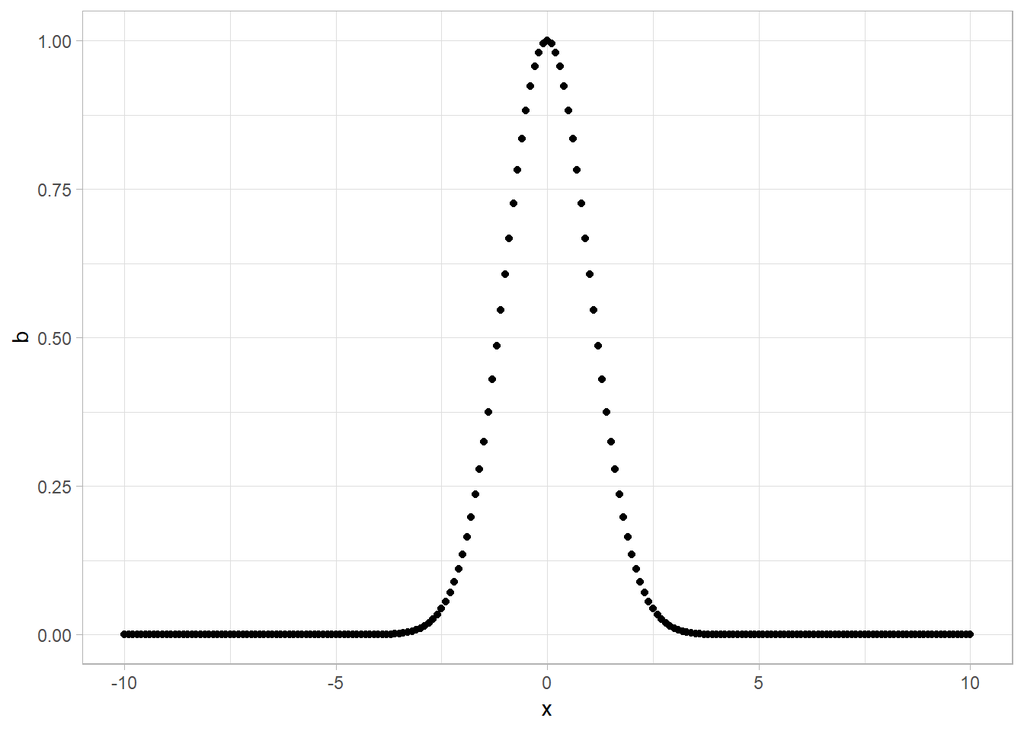

```r
x <- seq(-10, 10, 0.1)
d <- data.frame(x, a = sapply(x, fa), b = sapply(x, fb))

ggplot(d, aes(x, b)) + geom_point() + theme_light()
```

That’s looking pretty Gaussian now. So let’s put it all together.

### Combined

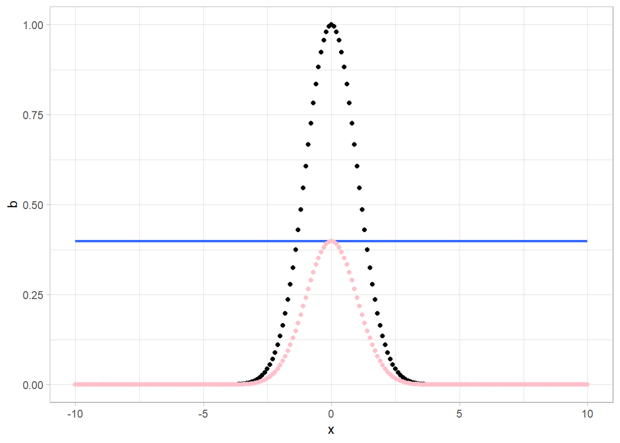

```r
fg <- function(x, sigma = 1, mu = 0) {
  fa(x, sigma, mu) * fb(x, sigma, mu)
}

d$g <- sapply(d$x, fg)

ggplot(d) +
  geom_point(aes(x, b)) +
  geom_smooth(aes(x, a)) +
  geom_point(aes(x, g), color = "pink") +
  theme_light()
```

The multiplication of each of the points has scaled the gaussian to peak at the constant’s value ($f(a)$).

## Combining gaussians

We can use a similar method to observe what happens when we combine gaussians.

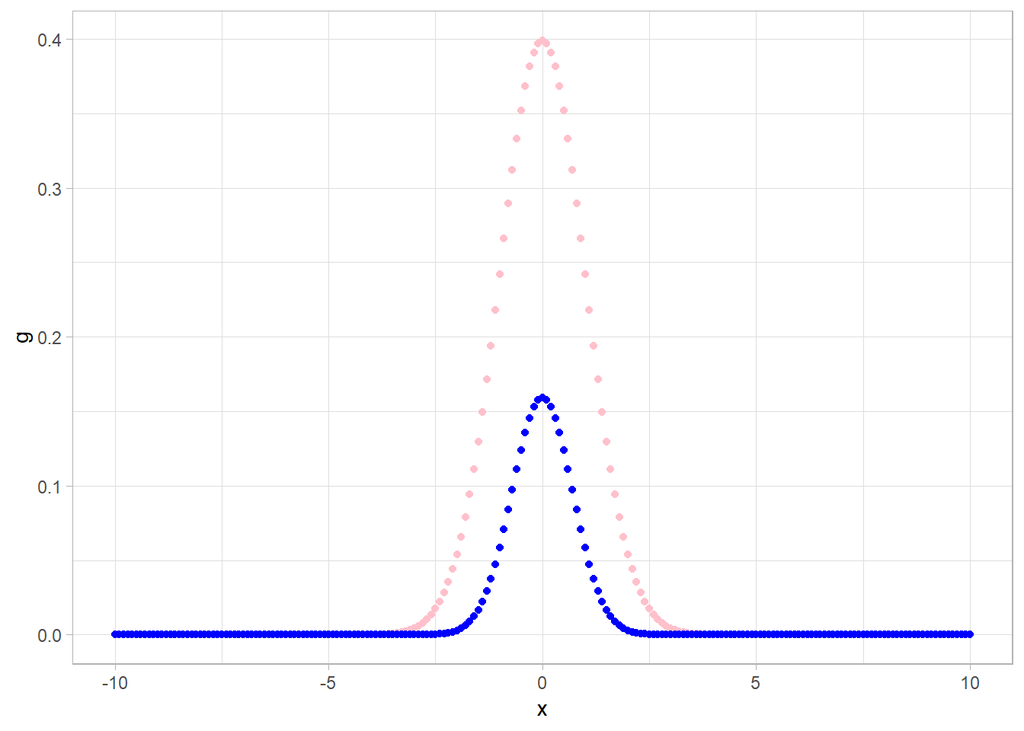

```r
d$g2 <- sapply(x, function(x) fg(x) * fg(x))

ggplot(d) +
  geom_point(aes(x, g), color = "pink") +
  geom_point(aes(x, g2), color = "blue") +
  theme_light()
```

Every point on the gaussian is reduced when it’s squared (because all points are < 1). This makes sense when we think in probability terms: to obtain contingent probabilities we multiply the probabilities together. So our initial points are the probabilities of some event, and the subsequent (blue) points are the probabilities of observing that event twice in succession.

## Standard deviation

The standard deviation ($\sigma$) is a key component of the distribution, and it occurs in both the curve and the constant. Let’s look at three values of the standard deviation:

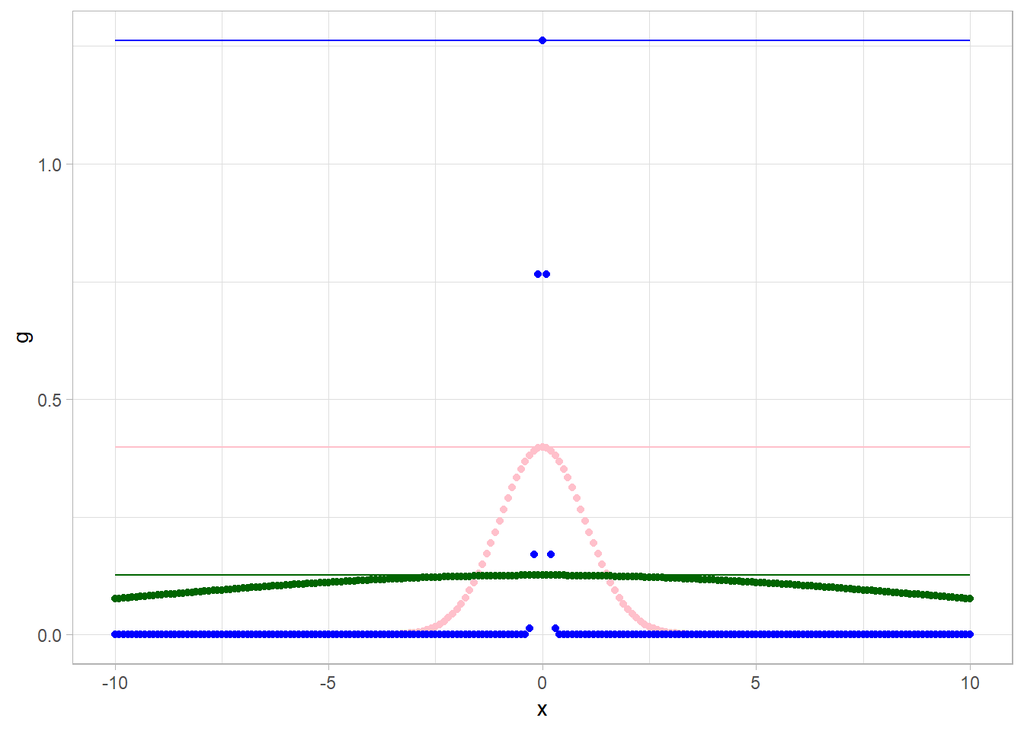

```r
d$sigLow <- sapply(d$x, fg, sigma = 0.1)
d$sigHigh <- sapply(d$x, fg, sigma = 10)

ggplot(d) +
  geom_point(aes(x, g), color = "pink") +
  geom_line(aes(x, a), color = "pink") +
  geom_point(aes(x, sigLow), color = "blue") +
  geom_line(aes(x, fa(x, sigma = 0.1)), color = "blue") +
  geom_point(aes(x, sigHigh), color = "darkgreen") +
  geom_line(aes(x, fa(x, sigma = 10)), color = "darkgreen") +
  theme_light()
```

As we already probably knew, the standard deviation is changing the sensitivity of the curve, in terms of how evenly its values are distributed over the range [-Infinity, Infinity].

Notice also, though, that the standard deviation is scaling the curve’s peak using the constant part. So the gaussian consists of a curve and a constant which controls the scaling.